# Ejercicios

Curso de Programación II

10/07/2021

| Alumno | Código |
| --- | --- |
| Valeria Llactayo Peña | 17160046 |
| Joaquin Romualdo Peña | 17150052 |
| Javier Sullcaray Barrientos | 17160201 |
| Jose Victorio Gonzales | 17160051 |
| Daniel Yauri Leiva | 17160208 |

## **Introducción**

> *Este documento R Markdown presenta la resolución de ejercicios del Curso de Programación II. Se adjunta el repositorio con los archivos utilizados en el siguiente [enlace](https://github.com/JoseVictorio/Ejercicios_Progra).*

```r
#Comenzaremos subiendo los datos que usaremos
load("datos.Rdata")
```

### *Parte 1*

Cargar las variables almacenadas en el siguiente archivo [RData](https://goo.gl/uDzU8v).

**1. Calcula los valores numéricos aproximados de:**

1. $\frac{0.3\cdot0.15}{0.3\cdot0.15+0.2\cdot0.8+0.5\cdot0.12}$

```r
a <- (0.3*0.15)/((0.3*0.15) + (0.2*0.8) + (0.5*0.12))
round(a, 2)
```

```
## [1] 0.17
```

2. $\frac{5^6}{6!}e^{-5}$

```r
b <- (5^6 / factorial(6)) * (exp(1))^(-5)
round(b, 2)
```

```
## [1] 0.15
```

```r
comb <- factorial(20) / (factorial(7) * (factorial(20-7)))
pot <- (0.4^7)*(0.6^13)

c <- comb * pot
round(c, 2)
```

```
## [1] 0.17
```

**2. Realizar la siguiente suma:**

1. $1+2+3+\ldots + 1000$

```r
Sn<-function(n){
 n*(n+1)/2
}
Sn(1000)
```

```
## [1] 500500
```

2. $1+2+4+8+16+\ldots + 1024$

```r
Sx<-function(a1, r, n){
a1*(r**n-1)/(r-1)
}
Sx(1, 2, 11)
```

```
## [1] 2047
```

**3. El vector `grupo` representa el grupo al que pertenece una serie de alumnos:**

1. ¿Cuántos elementos tiene?

```r
grupo
```

```
##   [1] "B" "A" "E" "D" "B" "D" "D" "A" "D" "C" "D" "E" "B" "E" "E" "E" "A" "B"
##  [19] "C" "C" "A" "C" "C" "D" "D" "E" "E" "A" "B" "C" "C" "E" "D" "C" "E" "E"
##  [37] "E" "E" "D" "D" "D" "E" "E" "E" "D" "E" "B" "E" "D" "C" "E" "D" "E" "E"
##  [55] "C" "B" "D" "C" "E" "D" "E" "B" "D" "B" "B" "C" "D" "C" "C" "C" "E" "D"
##  [73] "E" "D" "C" "D" "E" "E" "C" "D" "C" "E" "D" "A" "B" "B" "E" "E" "C" "D"
##  [91] "C" "E" "E" "C" "E" "D" "D" "D" "E" "D" "A" "D" "B" "B" "C" "D" "E" "A"
## [109] "E" "E" "A" "C" "E" "D" "A" "D" "D" "C" "E" "E" "E" "D" "A" "E" "E" "E"
## [127] "C" "C" "B" "C" "C" "D" "C" "B" "C" "A" "D" "E" "D" "E" "E" "B" "E" "E"
## [145] "E" "E" "C" "B" "D" "D" "E" "E" "D" "D" "E" "D" "E" "D" "D" "C" "D" "D"
## [163] "D" "C" "E" "D" "E" "C" "E" "B" "C" "C" "C" "D" "D" "B" "D" "B" "E" "C"
## [181] "E" "D" "D" "E" "D" "B" "B" "E" "E" "A" "C" "A"
```

```r
table(grupo)
```

```
## grupo
##  A  B  C  D  E
## 14 23 39 54 62
```

```r
length(grupo)
```

```
## [1] 192
```

2. ¿En qué posiciones del vector está la letra “A”?

```r
which(grupo == "A")
```

```
##  [1]   2   8  17  21  28  84 101 108 111 115 123 136 190 192
```

**4. El vector `nota` representa la nota de un examen de los alumnos que están en los grupos del vector `grupo`.**

1. ¿Cuanto suman todas las notas?

```r
sum(nota)
```

```
## [1] 962
```

2. ¿Cual es la media aritmética de todas las notas?

```r
mean(nota)
```

```
## [1] 5.010417
```

3. ¿En qué posiciones están las notas mayores de 7.0?

```r
which(nota > 7.0)
```

```
##   C   B   E   E
##  81 103 120 151
```

4. Visualiza las notas ordenadas de mayor a menor

```r
sort(decreasing = T, nota)
```

```
##   E   E   B   C   E   E   E   D   E   C   C   B   E   E   B   B   C   D   E   D
## 7.7 7.5 7.4 7.2 7.0 6.9 6.9 6.8 6.8 6.8 6.8 6.8 6.6 6.5 6.4 6.4 6.4 6.4 6.3 6.2
##   C   C   C   C   E   D   D   C   D   C   C   D   E   B   C   C   E   E   E   D
## 6.2 6.2 6.2 6.2 6.2 6.1 6.1 6.1 6.1 6.0 6.0 6.0 6.0 6.0 6.0 5.9 5.9 5.9 5.9 5.9
##   E   D   B   B   C   E   B   D   D   C   E   D   E   D   E   A   D   C   C   C
## 5.9 5.9 5.9 5.9 5.8 5.8 5.8 5.8 5.8 5.7 5.7 5.7 5.7 5.7 5.6 5.6 5.6 5.6 5.6 5.6
##   C   D   E   B   A   E   D   E   E   C   D   D   E   A   D   E   E   D   D   C
## 5.5 5.5 5.5 5.5 5.5 5.5 5.5 5.5 5.5 5.5 5.5 5.5 5.5 5.4 5.4 5.4 5.4 5.4 5.4 5.4
##   B   D   E   D   E   E   A   E   C   E   E   E   D   B   E   B   C   E   E   E
## 5.4 5.3 5.3 5.3 5.3 5.2 5.2 5.2 5.2 5.2 5.2 5.2 5.1 5.0 5.0 5.0 5.0 5.0 5.0 5.0
##   D   E   B   E   E   D   D   E   E   C   E   E   B   A   E   A   E   D   E   D
## 5.0 5.0 4.9 4.9 4.9 4.9 4.9 4.9 4.8 4.8 4.8 4.8 4.8 4.8 4.7 4.7 4.7 4.7 4.7 4.7
##   D   C   C   B   E   C   B   D   B   B   E   C   A   C   D   C   C   D   A   C
## 4.7 4.7 4.7 4.7 4.6 4.6 4.6 4.6 4.5 4.5 4.5 4.5 4.5 4.5 4.4 4.4 4.4 4.4 4.4 4.4
##   D   D   B   A   B   D   B   C   E   D   E   D   A   A   A   D   D   D   D   A
## 4.4 4.3 4.3 4.3 4.2 4.2 4.2 4.2 4.2 4.2 4.2 4.2 4.1 4.1 4.1 4.1 4.1 4.0 4.0 4.0
##   E   C   C   E   B   D   C   E   D   D   D   D   E   E   D   D   C   D   C   E
## 4.0 4.0 4.0 3.9 3.9 3.8 3.8 3.8 3.7 3.7 3.7 3.7 3.6 3.6 3.6 3.5 3.4 3.4 3.4 3.4
##   C   D   E   E   E   E   D   A   E   D   D   B
## 3.2 3.2 3.2 3.1 3.0 2.9 2.9 2.9 2.7 2.6 2.5 1.7
```

5. ¿En qué posición está la nota máxima?

```r
which.max(nota)
```

```
##   E
## 120
```

**5. A partir de los vectores `grupo` y `nota` definidos.**

1. Suma las notas de los 10 primeros alumnos del vector

```r
sum(nota[1:10])
```

```
## [1] 51.8
```

2. ¿Cuántos alumnos hay del grupo C?

```r
grupo[grupo == "C"] %>% length()
```

```
## [1] 39
```

3. ¿Cuántos alumnos han aprobado?

```r
nota[nota>=5.5] %>% length()
```

```
## [1] 73
```

4. ¿Cuántos alumnos del grupo B han aprobado?

```r
grupo[(grupo == "B" & nota >=5.5)] %>% length()
```

```
## [1] 9
```

5. ¿Qué porcentaje de alumnos del grupo C han aprobado?

```r
x<- grupo[grupo == "C" & nota >=5.5] %>% length()
y<- grupo[grupo == "C"] %>% length
(x/y*100)
```

```
## [1] 51.28205
```

6. ¿De qué grupos son la máxima y mínima notas de toda la muestra?

```r
names(nota) <- grupo
which(nota == min(nota))
```

```
##   B
## 142
```

```r
which(nota == max(nota))
```

```
##   E
## 120
```

7. Nota media de los alumnos de grupo A y B, juntos, considerando sólo a los que han aprobado.

```r
mean(nota[grupo %in% c("A", "B") & nota>=5.5])
```

```
## [1] 6.109091
```

**6. Calcula el percentil 66 de las notas de todos los alumnos, y también de los alumnos del grupo C.**

```r
quantile(nota, 0.66)
```

```
## 66%
## 5.5
```

```r
quantile(nota[grupo == "C"], 0.66)
```

```
##   66%
## 5.808
```

**7. Un alumno tiene una nota de 4.9. ¿Qué porcentaje, del total de alumnos, tiene una nota menor o igual que la suya? ¿Y qué porcentaje tiene una nota mayor o igual que la suya?**

```r
length(nota[nota <= 4.9])/length(nota)*100
```

```
## [1] 46.875
```

```r
length(nota[nota >= 4.9])/length(nota)*100
```

```
## [1] 56.25
```

**8. Realiza el gráfico de diagramas de caja de las notas de cada grupo, para poder comparar el nivel de cada uno de ellos.**

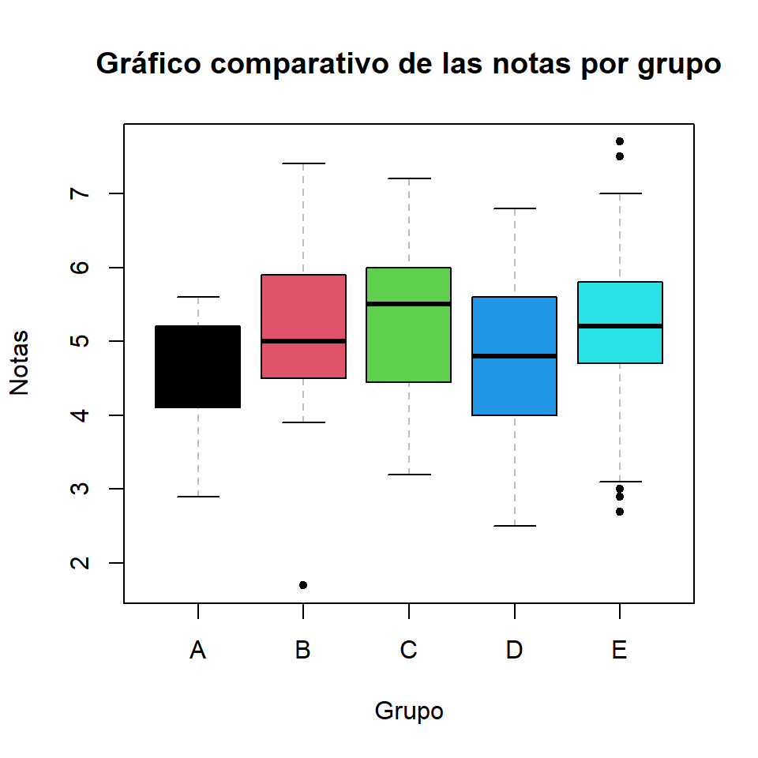

```r
  boxplot(nota~grupo,
          main = "Gráfico comparativo de las notas por grupo",
          xlab = "Grupo",
          ylab = "Notas",
          outpch =20,
          whiskcol = "grey",
          col = palette(rainbow(2))
  )
```

**9. Si la variable `conc` recoge la concentración de plomo (en ppm) en el aire de cierta zona durante un día completo**

1. ¿Cuál ha sido la concentración máxima?

```r
max(conc)
```

```
## [1] 47.34
```

2. ¿En cuántos de los muestreos se ha superado la concentración de 40.0 ppm?

```r
conc[conc>40] %>% length()
```

```
## [1] 61
```

3. ¿Cuál ha sido la concentración media del día?

```r
mean(conc)
```

```
## [1] 24.07229
```

4. ¿Cuáles fueron las 10 mediciones más bajas del día?

```r
sort(conc)[1:10]
```

```
##  [1] 0.93 1.07 1.77 2.03 2.58 2.73 2.75 2.88 2.88 2.91
```

5. Si la primera medida fue a las 00:00. ¿A qué hora del día se alcanzó la concentración máxima?

```r
#Hallando el intervalo para la toma de muestras
(24*60)/(length(conc))
```

```
## [1] 5
```

```r
as_tibble(conc) %>%
 mutate(hour = seq(
   as.POSIXct("2020-01-01 00:00"),
   as.POSIXct("2020-01-01 23:59"),
   by = "5 min"
 ))%>%
 print() %>%
 filter(value == max(value)) %>%
 print()
```

```
## # A tibble: 288 x 2
##    value hour
##    <dbl> <dttm>
##  1  4.76 2020-01-01 00:00:00
##  2  4.6  2020-01-01 00:05:00
##  3  6.14 2020-01-01 00:10:00
##  4  2.96 2020-01-01 00:15:00
##  5  3.15 2020-01-01 00:20:00
##  6  1.77 2020-01-01 00:25:00
##  7  4.36 2020-01-01 00:30:00
##  8  4    2020-01-01 00:35:00
##  9  2.03 2020-01-01 00:40:00
## 10  6.13 2020-01-01 00:45:00
## # ... with 278 more rows
## # A tibble: 1 x 2
##   value hour
##   <dbl> <dttm>
## 1  47.3 2020-01-01 11:45:00
```

### *Parte 2*

**1. 1.Graficar los puntos $(1,1),(2,4),(3,6),(4,8),(5,25),(6,36),(7,49),(8,61),(9,81),(10,100)$ en un plano utilizando RStudio.**

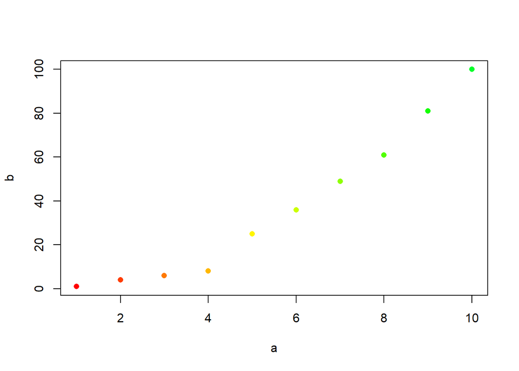

```r
a <- c(1, 2, 3, 4, 5, 6, 7, 8, 9, 10)
b <- c(1, 4, 6, 8, 25, 36, 49, 61, 81, 100)

plot(a, b, pch = 16, col = rainbow(25))
```

**2. Ingresar la matriz A en RStudio** $A = \begin{pmatrix} 1 & 2 & 3 \\ 2 & 4 & 6 \\ 3 & 6 & 9 \\ 4 & 8 & 12 \end{pmatrix}$

```r
A<-cbind(seq(1, 4),
         seq(2, 8, by = 2),
         seq(3, 12, by = 3))
A
```

```
##      [,1] [,2] [,3]
## [1,]    1    2    3
## [2,]    2    4    6
## [3,]    3    6    9
## [4,]    4    8   12
```

**3. Ingresar la matriz identidad de tamaño 3** $I = \begin{pmatrix} 1 & 0 & 0 \\ 0 & 1 & 0 \\ 0 & 0 & 1 \end{pmatrix}$

```r
diag(1, 3, 3)
```

```
##      [,1] [,2] [,3]
## [1,]    1    0    0
## [2,]    0    1    0
## [3,]    0    0    1
```

**4. Crea una función que cree una matriz nula ingresando las dimensiones**

```r
MatrizN <- function(k) {
  nula <- diag(k);
  for (i in 1:k) {
    nula[i, i] = 0
  };
  return(nula)
}
MatrizN(4)
```

```
##      [,1] [,2] [,3] [,4]
## [1,]    0    0    0    0
## [2,]    0    0    0    0
## [3,]    0    0    0    0
## [4,]    0    0    0    0
```

**5. Modificar la matriz `diag(4)`, para que se parezca a la matriz B** $B = \begin{pmatrix} 0 & 0 & 0 & 0 \\ 0 & 2 & 0 & 0 \\ 0 & 0 & 3 & 0 \\ 0 & 0 & 0 & 4 \end{pmatrix}$

```r
B<-diag(c(0, 2, 3, 4))
B
```

```
##      [,1] [,2] [,3] [,4]
## [1,]    0    0    0    0
## [2,]    0    2    0    0
## [3,]    0    0    3    0
## [4,]    0    0    0    4
```

**6. Obtener la matriz transpuesta de A (ejercicio 2)**

```r
t(A)
```

```
##      [,1] [,2] [,3] [,4]
## [1,]    1    2    3    4
## [2,]    2    4    6    8
## [3,]    3    6    9   12
```

```r
3*B
```

```
##      [,1] [,2] [,3] [,4]
## [1,]    0    0    0    0
## [2,]    0    6    0    0
## [3,]    0    0    9    0
## [4,]    0    0    0   12
```

```r
P<-matrix(c(1, -2, 1, 2, 4, 0, 3, -2, 1), nrow = 3, ncol =3)
P
```

```
##      [,1] [,2] [,3]
## [1,]    1    2    3
## [2,]   -2    4   -2
## [3,]    1    0    1
```

```r
Potencia <- function(n) {
  P**n
}
Potencia(6)
```

```
##      [,1] [,2] [,3]
## [1,]    1   64  729
## [2,]   64 4096   64
## [3,]    1    0    1
```

**9. Resolver el sistema de ecuaciones** $3x - y + z = -1\\9x - 2y + z = -9\\3x + y - 2z = -9$

```r
#Cargaremos la libreria "matlib" para usar la función Solve()
library(matlib)
```

```r
matriz01 <- matrix(c(3,9,3,-1,-2,1,1,1,-2), nrow = 3, ncol =3 )
matriz01
```

```
##      [,1] [,2] [,3]
## [1,]    3   -1    1
## [2,]    9   -2    1
## [3,]    3    1   -2
```

```r
matriz02<- matrix(c(-1, -9, -9), nrow = 3, ncol = 1)
matriz02
```

```
##      [,1]
## [1,]   -1
## [2,]   -9
## [3,]   -9
```

```r
Solve(matriz01, matriz02)
```

```
## x1      =  -1
##   x2    =   2
##     x3  =   4
```

**10. Utilizando la ayuda de R, investigue para qué sirven las funciones `eigen()` y `det()`**

- det() = nos calcula el determinante de una matriz cuadrada
- eigen() = Calcula autovalores y autovectores de matrices numéricas (dobles, enteras, lógicas) o complejas.

**11. Considerando las matrices**

$B= \begin{pmatrix} 1 & 2 & 3 & 4 & 5 \\ 2 & 4 & 6 & 8 & 10 \\ 3 & 6 & 9 & 12 & 15 \\ 4 & 8 & 12 & 16 & 20 \\ 5 & 10 & 15 & 20 & 25 \\ 6 & 12 & 18 & 24 & 30 \\ 7 & 14 & 21 & 28 & 35 \\ 8 & 16 & 24 & 32 & 40 \\ 9 & 18 & 27 & 36 & 45 \\ 10 & 20 & 30 & 40 & 50 \end{pmatrix}$

$A = \begin{pmatrix} 0 & 1 & 0 & 1 & 0 \\ 1 & 0 & 1 & 0 & 1 \\ 0 & 1 & 0 & 1 & 0 \\ 0 & 1 & 0 & 0 & 1 \\ 1 & 0 & 1 & 1 & 0 \\ \end{pmatrix}$

Calcular $A \cdot B - A B^t$

```r
MA <- cbind(c(1:10),
           seq(2, 20, by = 2),
           seq(3, 30, by = 3),
           seq(4, 40, by = 4),
           seq(5, 50, by = 5))

MB <- cbind(c(0, 1, 0, 0, 1),
           c(1, 0, 1, 1, 0),
           c(0, 1, 0, 0, 1),
           c(1, 0, 1, 0, 1),
           c(0, 1, 0, 1, 0))

(MA %*% MB) - (MA %*% (t(MB))) #t() para calcular la matriz transpuesta
```

```
##       [,1] [,2] [,3] [,4] [,5]
##  [1,]    1   -1    1    2   -2
##  [2,]    2   -2    2    4   -4
##  [3,]    3   -3    3    6   -6
##  [4,]    4   -4    4    8   -8
##  [5,]    5   -5    5   10  -10
##  [6,]    6   -6    6   12  -12
##  [7,]    7   -7    7   14  -14
##  [8,]    8   -8    8   16  -16
##  [9,]    9   -9    9   18  -18
## [10,]   10  -10   10   20  -20
```

```r
#Otra forma de calcular la matriz transpuesta de B:
#B <- matrix(B, nrow = 5, ncol = 5, byrow = T)
```

**12. Considere** $\hat\beta = (X^t \cdot X)^{-1} \cdot X^t \cdot Y$

Determine la matriz $\hat\beta$

$y = \begin{pmatrix}0\\0\\1\\1\\3\\\end{pmatrix}$

```r
x <- cbind(c(1:5), c(1, -1, 0, 1, 2))
y <- cbind(c(0, 0, 1, 1, 3))

(solve(t(x) %*% x)) %*% t(x) %*% y #solve() calcula la inversa de la matriz
```

```
##           [,1]
## [1,] 0.2916667
## [2,] 0.4583333
```

**13. Corre el siguiente código para cargar los vectores `year` y `co2`** en memoria

```r
data(co2)
means = aggregate(co2, FUN=mean)
year = as.vector(time(means))
co2 = as.vector(means)
```

- El vector `co2` contiene medidas de $CO_2$ en la atmósfera, en unidades de *ppm*, durante el periodo 1959-1997. El vector `year` contiene sus años correspondientes.
- Calcular un vector de diferencias de $CO_2$ entre años consecutivos, que sería:
  - $CO_2$ en 1960 menos $CO_2$ en 1959
  - $CO_2$ en 1961 menos $CO_2$ en 1960
  - y así sucesivamente…

```r
co2
```

```
##  [1] 315.8258 316.7475 317.4850 318.2975 318.8325 319.4625 319.8725 321.2100
##  [9] 322.0200 322.8900 324.4592 325.5175 326.1550 327.2933 329.5117 330.0792
## [17] 330.9858 331.9858 333.7300 335.3358 336.6808 338.5150 339.7608 340.9592
## [25] 342.6083 344.2467 345.7258 346.9750 348.7508 351.3133 352.7542 354.0367
## [33] 355.4783 356.2917 356.9958 358.8800 360.9142 362.6867 363.8175
```

```r
#Corremos los datos del vector a la derecha con lag()
lag(co2)
```

```
##  [1]       NA 315.8258 316.7475 317.4850 318.2975 318.8325 319.4625 319.8725
##  [9] 321.2100 322.0200 322.8900 324.4592 325.5175 326.1550 327.2933 329.5117
## [17] 330.0792 330.9858 331.9858 333.7300 335.3358 336.6808 338.5150 339.7608
## [25] 340.9592 342.6083 344.2467 345.7258 346.9750 348.7508 351.3133 352.7542
## [33] 354.0367 355.4783 356.2917 356.9958 358.8800 360.9142 362.6867
```

```r
dif <- co2 - dplyr::lag(co2)
dif
```

```
##  [1]        NA 0.9216667 0.7375000 0.8125000 0.5350000 0.6300000 0.4100000
##  [8] 1.3375000 0.8100000 0.8700000 1.5691667 1.0583333 0.6375000 1.1383333
## [15] 2.2183333 0.5675000 0.9066667 1.0000000 1.7441667 1.6058333 1.3450000
## [22] 1.8341667 1.2458333 1.1983333 1.6491667 1.6383333 1.4791667 1.2491667
## [29] 1.7758333 2.5625000 1.4408333 1.2825000 1.4416667 0.8133333 0.7041667
## [36] 1.8841667 2.0341667 1.7725000 1.1308333
```

- Crear un **plot** con lineas y puntos mostrando las diferencias consecutivas de $CO_2$ en función del tiempo (1960, 1961, etc…), en **negrita**

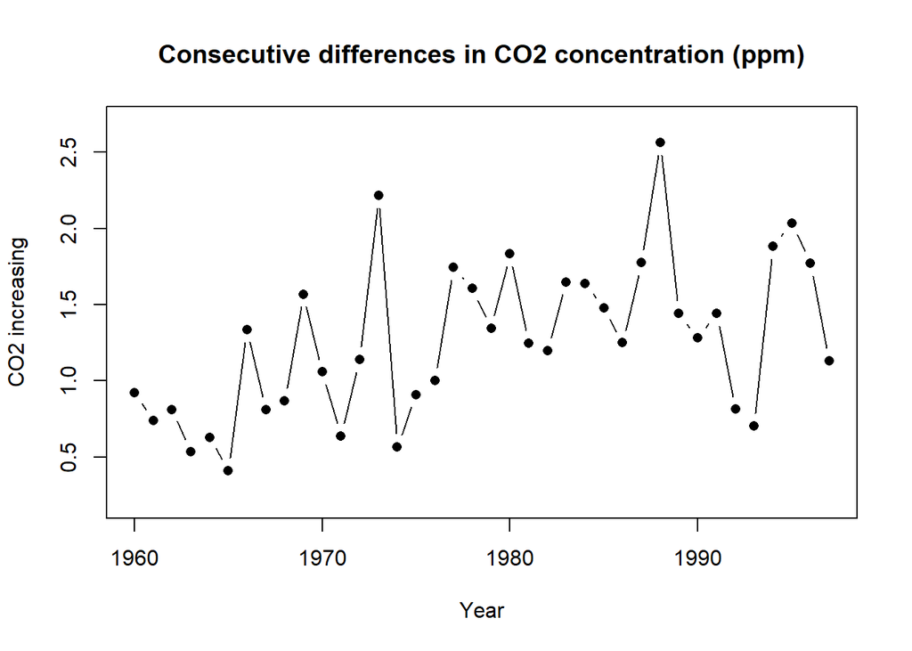

```r
plot(x = year, y = dif,
     type = "b",
     pch = 16,
     xlab = "Year",
     ylab = "CO2 increasing",
     main = "Consecutive differences in CO2 concentration (ppm)",
     xlim = c(1960, 1997),
     ylim = c(0.2, 2.7)
     )
```

- La diferencia de concentración de $CO_2$ entre 2020 y 2019 fue igual a 2.64. Agregar un punto rojo representando esa diferencia al plot ya creado (usar una forma diferente, como `pch=4`)

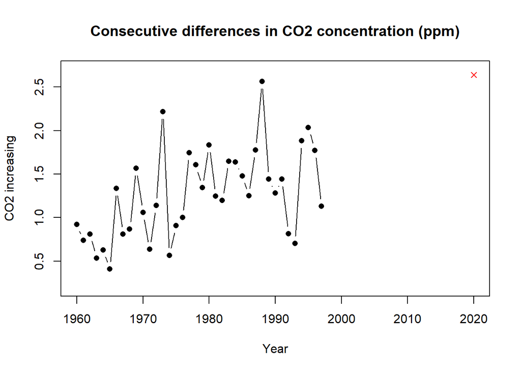

```r
dif_2020_2019 <- 2.64
year_2020 <- 2020

plot(x = year, y = dif,
     type = "b",
     pch = 16,
     xlab = "Year",
     ylab = "CO2 increasing",
     main = "Consecutive differences in CO2 concentration (ppm)",
     xlim = c(1960, 2020),
     ylim = c(0.2, 2.7))
points(x = year_2020, y = dif_2020_2019, pch = 4, col = "red")
```

**14.**

- Lee el archivo `rainfall.csv` como un `data.frame`
- Calcula e imprime un vector con los nombres de las estaciones donde al menos uno de los meses tiene una precipitación superior a 180mm.

```r
rainf <- read_csv("rainfall.csv") %>%
  select(sep:name) %>% #seleccionamos las columnas con las que trabajaremos
  gather(key = "mes", value = "pp", 1:9) %>% #acomodamos los datos en dos columnas
  filter(pp >= 180) %>% #aplicamos el filtro a la columna "pp"
  print() %>%
  collect %>% .[[1]] %>% #visualizamos el resultado de las estaciones en un vector
  print()
```

```
## # A tibble: 12 x 3
##    name       mes      pp
##    <chr>      <chr> <dbl>
##  1 Horashim   dec     202
##  2 Golan Farm jan     201
##  3 Eilon      jan     201
##  4 Fasutta    jan     205
##  5 Yehiam     jan     204
##  6 Kfar Mahol jan     209
##  7 Meron      jan     220
##  8 Horashim   jan     238
##  9 Golan Farm feb     196
## 10 Kfar Mahol feb     183
## 11 Meron      feb     192
## 12 Horashim   feb     190
##  [1] "Horashim"   "Golan Farm" "Eilon"      "Fasutta"    "Yehiam"
##  [6] "Kfar Mahol" "Meron"      "Horashim"   "Golan Farm" "Kfar Mahol"
## [11] "Meron"      "Horashim"
```

### *Parte 3*

**15. Manipule los dataframe según se solicite**

Utilizando el csv **(raingaugeDataset.csv)** de datos de precipitación diaria (período 1980 - 2013) de la estación “LAMBAYEQUE” con código único *“qc00000301”*, para obtenerlo, realizamos lo siguiente:

```r
#filtrando los datos de nuestra estación en el archivo "listRaingauge.csv"
MetEst <- read_csv("listRaingauge.csv") %>%
  filter(DEPARTAMENTO == "LAMBAYEQUE", NOM_EST == "LAMBAYEQUE")
MetEst
```

```
## # A tibble: 1 x 6
##   DEPARTAMENTO NOM_EST    CODIGO       LON   LAT   ALT
##   <chr>        <chr>      <chr>      <dbl> <dbl> <dbl>
## 1 LAMBAYEQUE   LAMBAYEQUE qc00000301  79.9  6.73    18
```

```r
#trabajando con los datos de precipitación
dataL <- read_csv("raingaugeDataset.csv") %>%
  select(date, "qc00000301") %>% #seleccionando la columna de nuestra estación
  mutate(date = as.Date(date, format = "%d/%m/%Y")) %>% #dandole un formato de fecha a la columna date"
  rename(pp = qc00000301) %>% #renombramos la columna
  arrange(date) #ordenamos los datos
dataL
```

```
## # A tibble: 12,419 x 2
##    date          pp
##    <date>     <dbl>
##  1 1980-01-01     0
##  2 1980-01-02     0
##  3 1980-01-03     0
##  4 1980-01-04     0
##  5 1980-01-05     0
##  6 1980-01-06     0
##  7 1980-01-07     0
##  8 1980-01-08     0
##  9 1980-01-09     0
## 10 1980-01-10     0
## # ... with 12,409 more rows
```

```r
#comprobando que los datos estén completos

tail(dataL) #visualizando la fecha del último dato
```

```
## # A tibble: 6 x 2
##   date          pp
##   <date>     <dbl>
## 1 2013-12-26     0
## 2 2013-12-27     0
## 3 2013-12-28     0
## 4 2013-12-29     0
## 5 2013-12-30     0
## 6 2013-12-31     0
```

```r
#obteniendo el numero de datos del periodo 1980-2013
seq(as.Date("1980-01-01"), as.Date("2013-12-31"), by = "day") %>%
  length()
```

```
## [1] 12419
```

1. Determine la cantidad de missing values de la serie de tiempo a paso diario.

```r
NAVALUES <-
  dataL %>%
  mutate( #creando variable que indicará el número de missing values de cada mes
    misVal = is.na(pp) #retorna la suma del conteo de NA de la columna "pp"
  )
NAVALUES
```

```
## # A tibble: 12,419 x 3
##    date          pp misVal
##    <date>     <dbl> <lgl>
##  1 1980-01-01     0 FALSE
##  2 1980-01-02     0 FALSE
##  3 1980-01-03     0 FALSE
##  4 1980-01-04     0 FALSE
##  5 1980-01-05     0 FALSE
##  6 1980-01-06     0 FALSE
##  7 1980-01-07     0 FALSE
##  8 1980-01-08     0 FALSE
##  9 1980-01-09     0 FALSE
## 10 1980-01-10     0 FALSE
## # ... with 12,409 more rows
```

```r
#obteniendo la suma de NA
summarise(NAVALUES,
          naVal = sum(misVal)) %>%
  print()
```

```
## # A tibble: 1 x 1
##   naVal
##   <int>
## 1   666
```

2. Calcule la serie de tiempo de precipitación **acumulada mensual** (si el # de días con missing values, en un mes, supera el 10 %, la precipitación acumulada mensual será considerado como un **`NA`**).

```r
ppMonth <-
  NAVALUES %>%
  group_by(date = str_sub(date, 1,7)) %>% #extraemos solo el año y el més de la columna "date"
  mutate( #indicara el nro de missing values de cada mes
    misVal = sum(is.na(pp))*100/n() #retorna la suma del conteo de NA de la columna "pp" y lo convierte a %
  ) %>%
  summarise( #creara una tabla resumen con la precipitación acumulada y su % de NA
    pp = sum(pp, na.rm = T ),#suma de la pp por mes
    misVal = unique(misVal) #para obtener los valores únicos de porcentaje
  ) %>%
  mutate(
    pp = ifelse(misVal >= 10, NA, pp),#si misVal es igual o mayor a 10, se convierte en NA, de lo contrario, conserva su valor
    month = str_sub(date, 6,7) #agregamos la columna con los el mes que corresponde a cada dato
  ) %>%
  print()
```

```
## # A tibble: 408 x 4
##    date       pp misVal month
##    <chr>   <dbl>  <dbl> <chr>
##  1 1980-01  0.31    0   01
##  2 1980-02  0.1     0   02
##  3 1980-03  2.72    0   03
##  4 1980-04  0.3     0   04
##  5 1980-05  0.21    0   05
##  6 1980-06  0       0   06
##  7 1980-07  0       0   07
##  8 1980-08  0       0   08
##  9 1980-09 NA      46.7 09
## 10 1980-10  0.95    0   10
## # ... with 398 more rows
```

3. Determine la cantidad de **missing values** de la serie de tiempo a paso mensual.

```r
naCant <-
  ppMonth%>%
  summarise(isNa = sum(is.na(pp))) %>%
  print()
```

```
## # A tibble: 1 x 1
##    isNa
##   <int>
## 1    25
```

4. Cree una función que calcule, a partir de los datos de preicpitación mensual, la **climatología (Ene-Dic)** para el **período 1980-2010**.

```r
pp_mean <- function(data){
  periodo <- filter(data, date >= "1980-01-01" & date <="2010-12-31")
   meses <- group_by(periodo, month)
  media <- summarise(meses, ppmean= mean(pp, na.rm = T))
  return (media)
}

pp_mean(ppMonth)
```

```
## # A tibble: 12 x 2
##    month  ppmean
##    <chr>   <dbl>
##  1 01     5.35
##  2 02     8.59
##  3 03    16.3
##  4 04     6.56
##  5 05     2.15
##  6 06     0.717
##  7 07     0.0832
##  8 08     0.153
##  9 09     0.273
## 10 10     0.948
## 11 11     1.49
## 12 12     1.79
```

5. Poltear (boxplot) la variabilidad de los valores mensuales (Ene-Dic) para el período 1980-2013.

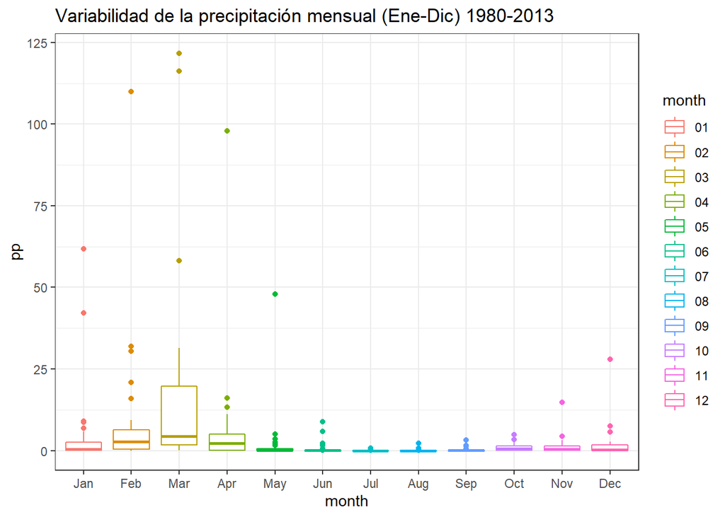

```r
  ggplot(ppMonth, aes(month, pp, color = month)) + #en el eje x van los meses
    ggtitle("Variabilidad de la precipitación mensual (Ene-Dic) 1980-2013")+
    geom_boxplot()+ #definimos la geometria de boxplot
    theme_bw()+ #se le agrega un tema
    scale_x_discrete( #le damos la etiqueta a los meses
      labels = month.abb #.abb primeras tres letras ene, feb, mar, etc
    )
```